# Apple Store Apps Exploration

## Introduction

I will be exploring a dataset of apps on the Apple Store, it contains info such as prices and ratings of them. It was published on Kaggle by Ramanathan [here](https://www.kaggle.com/ramamet4/app-store-apple-data-set-10k-apps)

```python
import pandas as pd
import numpy as np
import matplotlib.pyplot as plt
import seaborn as sb

%matplotlib inline
```

```python
apps = pd.read_csv('AppleStore.csv')
```

```python
apps.head()
```

|  | Unnamed: 0 | id | track_name | size_bytes | currency | price | rating_count_tot | rating_count_ver | user_rating | user_rating_ver | ver | cont_rating | prime_genre | sup_devices.num | ipadSc_urls.num | lang.num | vpp_lic |
| --- | --- | --- | --- | --- | --- | --- | --- | --- | --- | --- | --- | --- | --- | --- | --- | --- | --- |
| 0 | 1 | 281656475 | PAC-MAN Premium | 100788224 | USD | 3.99 | 21292 | 26 | 4.0 | 4.5 | 6.3.5 | 4+ | Games | 38 | 5 | 10 | 1 |
| 1 | 2 | 281796108 | Evernote - stay organized | 158578688 | USD | 0.00 | 161065 | 26 | 4.0 | 3.5 | 8.2.2 | 4+ | Productivity | 37 | 5 | 23 | 1 |
| 2 | 3 | 281940292 | WeatherBug - Local Weather, Radar, Maps, Alerts | 100524032 | USD | 0.00 | 188583 | 2822 | 3.5 | 4.5 | 5.0.0 | 4+ | Weather | 37 | 5 | 3 | 1 |
| 3 | 4 | 282614216 | eBay: Best App to Buy, Sell, Save! Online Shop... | 128512000 | USD | 0.00 | 262241 | 649 | 4.0 | 4.5 | 5.10.0 | 12+ | Shopping | 37 | 5 | 9 | 1 |
| 4 | 5 | 282935706 | Bible | 92774400 | USD | 0.00 | 985920 | 5320 | 4.5 | 5.0 | 7.5.1 | 4+ | Reference | 37 | 5 | 45 | 1 |

```python
apps.info()
```

```
<class 'pandas.core.frame.DataFrame'>
RangeIndex: 7197 entries, 0 to 7196
Data columns (total 17 columns):
Unnamed: 0          7197 non-null int64
id                  7197 non-null int64
track_name          7197 non-null object
size_bytes          7197 non-null int64
currency            7197 non-null object
price               7197 non-null float64
rating_count_tot    7197 non-null int64
rating_count_ver    7197 non-null int64
user_rating         7197 non-null float64
user_rating_ver     7197 non-null float64
ver                 7197 non-null object
cont_rating         7197 non-null object
prime_genre         7197 non-null object
sup_devices.num     7197 non-null int64
ipadSc_urls.num     7197 non-null int64
lang.num            7197 non-null int64
vpp_lic             7197 non-null int64
dtypes: float64(3), int64(9), object(5)
memory usage: 956.0+ KB
```

```python
apps['prime_genre'].value_counts(),apps['cont_rating'].value_counts()
```

```
(Games                3862
 Entertainment         535
 Education             453
 Photo & Video         349
 Utilities             248
 Health & Fitness      180
 Productivity          178
 Social Networking     167
 Lifestyle             144
 Music                 138
 Shopping              122
 Sports                114
 Book                  112
 Finance               104
 Travel                 81
 News                   75
 Weather                72
 Reference              64
 Food & Drink           63
 Business               57
 Navigation             46
 Medical                23
 Catalogs               10
 Name: prime_genre, dtype: int64,
 4+     4433
 12+    1155
 9+      987
 17+     622
 Name: cont_rating, dtype: int64)
```

```python
apps.describe()
```

|  | Unnamed: 0 | id | size_bytes | price | rating_count_tot | rating_count_ver | user_rating | user_rating_ver | sup_devices.num | ipadSc_urls.num | lang.num | vpp_lic |
| --- | --- | --- | --- | --- | --- | --- | --- | --- | --- | --- | --- | --- |
| count | 7197.000000 | 7.197000e+03 | 7.197000e+03 | 7197.000000 | 7.197000e+03 | 7197.000000 | 7197.000000 | 7197.000000 | 7197.000000 | 7197.000000 | 7197.000000 | 7197.000000 |
| mean | 4759.069612 | 8.631310e+08 | 1.991345e+08 | 1.726218 | 1.289291e+04 | 460.373906 | 3.526956 | 3.253578 | 37.361817 | 3.707100 | 5.434903 | 0.993053 |
| std | 3093.625213 | 2.712368e+08 | 3.592069e+08 | 5.833006 | 7.573941e+04 | 3920.455183 | 1.517948 | 1.809363 | 3.737715 | 1.986005 | 7.919593 | 0.083066 |
| min | 1.000000 | 2.816565e+08 | 5.898240e+05 | 0.000000 | 0.000000e+00 | 0.000000 | 0.000000 | 0.000000 | 9.000000 | 0.000000 | 0.000000 | 0.000000 |
| 25% | 2090.000000 | 6.000937e+08 | 4.692275e+07 | 0.000000 | 2.800000e+01 | 1.000000 | 3.500000 | 2.500000 | 37.000000 | 3.000000 | 1.000000 | 1.000000 |
| 50% | 4380.000000 | 9.781482e+08 | 9.715302e+07 | 0.000000 | 3.000000e+02 | 23.000000 | 4.000000 | 4.000000 | 37.000000 | 5.000000 | 1.000000 | 1.000000 |
| 75% | 7223.000000 | 1.082310e+09 | 1.819249e+08 | 1.990000 | 2.793000e+03 | 140.000000 | 4.500000 | 4.500000 | 38.000000 | 5.000000 | 8.000000 | 1.000000 |
| max | 11097.000000 | 1.188376e+09 | 4.025970e+09 | 299.990000 | 2.974676e+06 | 177050.000000 | 5.000000 | 5.000000 | 47.000000 | 5.000000 | 75.000000 | 1.000000 |

```python
apps.id.nunique(),apps.iloc[:,1].nunique(), apps.track_name.nunique()
```

```
(7197, 7197, 7195)
```

```python
apps[apps.track_name.duplicated()]
```

|  | Unnamed: 0 | id | track_name | size_bytes | currency | price | rating_count_tot | rating_count_ver | user_rating | user_rating_ver | ver | cont_rating | prime_genre | sup_devices.num | ipadSc_urls.num | lang.num | vpp_lic |
| --- | --- | --- | --- | --- | --- | --- | --- | --- | --- | --- | --- | --- | --- | --- | --- | --- | --- |
| 5603 | 7579 | 1089824278 | VR Roller Coaster | 240964608 | USD | 0.0 | 67 | 44 | 3.5 | 4.0 | 0.81 | 4+ | Games | 38 | 0 | 1 | 1 |
| 7128 | 10885 | 1178454060 | Mannequin Challenge | 59572224 | USD | 0.0 | 105 | 58 | 4.0 | 4.5 | 1.0.1 | 4+ | Games | 38 | 5 | 1 | 1 |

```python
apps[(apps.track_name == 'VR Roller Coaster') | (apps.track_name == 'Mannequin Challenge')]
```

|  | Unnamed: 0 | id | track_name | size_bytes | currency | price | rating_count_tot | rating_count_ver | user_rating | user_rating_ver | ver | cont_rating | prime_genre | sup_devices.num | ipadSc_urls.num | lang.num | vpp_lic |
| --- | --- | --- | --- | --- | --- | --- | --- | --- | --- | --- | --- | --- | --- | --- | --- | --- | --- |
| 3319 | 4000 | 952877179 | VR Roller Coaster | 169523200 | USD | 0.0 | 107 | 102 | 3.5 | 3.5 | 2.0.0 | 4+ | Games | 37 | 5 | 1 | 1 |
| 5603 | 7579 | 1089824278 | VR Roller Coaster | 240964608 | USD | 0.0 | 67 | 44 | 3.5 | 4.0 | 0.81 | 4+ | Games | 38 | 0 | 1 | 1 |
| 7092 | 10751 | 1173990889 | Mannequin Challenge | 109705216 | USD | 0.0 | 668 | 87 | 3.0 | 3.0 | 1.4 | 9+ | Games | 37 | 4 | 1 | 1 |
| 7128 | 10885 | 1178454060 | Mannequin Challenge | 59572224 | USD | 0.0 | 105 | 58 | 4.0 | 4.5 | 1.0.1 | 4+ | Games | 38 | 5 | 1 | 1 |

### Dataset Structure Notes

The dataset contains 7195 unique apps.  
Apart from the unnamed, id and app name, there are 14 other features of every app, which are described here briefly with some notes:

- "size_bytes": Size (in Bytes)
- "currency": Currency Type
- "price": Price amount
- "ratingcounttot": User Rating counts (for all version)
- "ratingcountver": User Rating counts (for current version)
- "user_rating" : Average User Rating value (for all version)
- "userratingver": Average User Rating value (for current version)
- "ver" : Latest version code
- "cont_rating": Content Rating (That's the age: 4+, 9+, 12+, 17+)
- "prime_genre": Primary Genre
- "sup_devices.num": Number of supporting devices
- "ipadSc_urls.num": Number of screenshots showed for display
- "lang.num": Number of supported languages
- "vpp_lic": Vpp Device Based Licensing Enabled. Wether or not the app could be bought with others in a bulk purchase. This is important for organizations so I will keep it.

### Goal of analysis

I will be looking at apps with the best ratings, to answer questions like: What characteristics do they have? What features contribute the most to their high rating? Are they mostly Paid or Free?

I believe the primary variables that will have a strong effect are: price, supported devices, supported languages, and the genre.  
Other features will have an effect but probably not as much.

I will also explore other variables and features and how they correlate, without necessarily relating to the ratings.  
So I will answer questions like: Which genres have more Paid than Free apps? Do specific genres support more langauges or devices than others? Which genres have the largest app sizes?

## Cleaning

There are some cleaning and preprocessing steps I need to take before performing my analysis.  
I will write comments wherever possible so that following the steps will be as smooth as possible.

```python
#Convert some column names
new_col_names = {"track_name":"app_name","rating_count_tot":"ratings_count_tot","rating_count_ver":"ratings_count_ver","user_rating":"avg_ratings","user_rating_ver":"avg_ratings_ver",
                 "cont_rating":"content_rating","prime_genre":"genre","sup_devices.num":"supp_devices_count","ipadSc_urls.num":"sc_count","lang.num":"lang_count"}
apps.rename(columns=new_col_names,inplace=True)
apps.columns
```

```
Index(['Unnamed: 0', 'id', 'app_name', 'size_bytes', 'currency', 'price',
       'ratings_count_tot', 'ratings_count_ver', 'avg_ratings',
       'avg_ratings_ver', 'ver', 'content_rating', 'genre',
       'supp_devices_count', 'sc_count', 'lang_count', 'vpp_lic'],
      dtype='object')
```

```python
#Remove duplicates. There are only two apps with the same name, but they have different versions.
#Since there are only two apps with more than one version, I can remove them safely.
idx = apps[apps.app_name.duplicated(keep=False)]
#Get the minimum versions. Locate it through indexing then get the index.
apps.drop(idx[idx.ver.isin(idx.groupby('app_name').ver.min())].index,inplace=True)
apps.reset_index(drop=True,inplace=True)
```

```python
#Remove useless columns
apps.drop(['Unnamed: 0','currency'],axis=1,inplace=True)
```

```python
#Converts columns to appropriate types where needed.

#Set the order for the content rating column category
ordinal_content_rating = ['4+','9+','12+','17+']

ordered_cont = pd.api.types.CategoricalDtype(ordered=True,categories=ordinal_content_rating)
apps.content_rating = apps.content_rating.astype(ordered_cont)
#No order needed here, just convert the column type to category.
apps.genre = apps.genre.astype('category')
```

```python
#Convert size_bytes column values to megabytes
apps['size_bytes'] = (apps['size_bytes'] / (10 ** 6)).astype('float64')
apps.rename(columns={'size_bytes':'size_mb'},inplace=True)
```

```python
print(apps.dtypes)
print(apps.shape)
apps.head()
```

```
id                       int64
app_name                object
size_mb                float64
price                  float64
ratings_count_tot        int64
ratings_count_ver        int64
avg_ratings            float64
avg_ratings_ver        float64
ver                     object
content_rating        category
genre                 category
supp_devices_count       int64
sc_count                 int64
lang_count               int64
vpp_lic                  int64
dtype: object
(7195, 15)
```

|  | id | app_name | size_mb | price | ratings_count_tot | ratings_count_ver | avg_ratings | avg_ratings_ver | ver | content_rating | genre | supp_devices_count | sc_count | lang_count | vpp_lic |
| --- | --- | --- | --- | --- | --- | --- | --- | --- | --- | --- | --- | --- | --- | --- | --- |
| 0 | 281656475 | PAC-MAN Premium | 100.788224 | 3.99 | 21292 | 26 | 4.0 | 4.5 | 6.3.5 | 4+ | Games | 38 | 5 | 10 | 1 |
| 1 | 281796108 | Evernote - stay organized | 158.578688 | 0.00 | 161065 | 26 | 4.0 | 3.5 | 8.2.2 | 4+ | Productivity | 37 | 5 | 23 | 1 |
| 2 | 281940292 | WeatherBug - Local Weather, Radar, Maps, Alerts | 100.524032 | 0.00 | 188583 | 2822 | 3.5 | 4.5 | 5.0.0 | 4+ | Weather | 37 | 5 | 3 | 1 |
| 3 | 282614216 | eBay: Best App to Buy, Sell, Save! Online Shop... | 128.512000 | 0.00 | 262241 | 649 | 4.0 | 4.5 | 5.10.0 | 12+ | Shopping | 37 | 5 | 9 | 1 |
| 4 | 282935706 | Bible | 92.774400 | 0.00 | 985920 | 5320 | 4.5 | 5.0 | 7.5.1 | 4+ | Reference | 37 | 5 | 45 | 1 |

```python
#Defining some colors.
blue  = sb.color_palette()[0]
orange = sb.color_palette()[1]
green = sb.color_palette()[2]
red = sb.color_palette()[3]
light_blue = '#465362'#64a2ad'
dark_blue = '#011936'
light_orange = '#F4C43F'#e9c16a'
pink = '#ED254E'
dark_gold = '#C2A83E'
dark_green= '#244C38'
light_green = '#62C370'
#2274A5
#E6AF2E
#587792
#F2ED6F
#CEE397
```

## Univariate Exploration

Here I will explore different variables and features each on its own.  
Let's start with the average ratings:

```python
apps.avg_ratings.value_counts()
```

```
4.5    2663
4.0    1625
0.0     929
3.5     701
5.0     492
3.0     383
2.5     196
2.0     106
1.5      56
1.0      44
Name: avg_ratings, dtype: int64
```

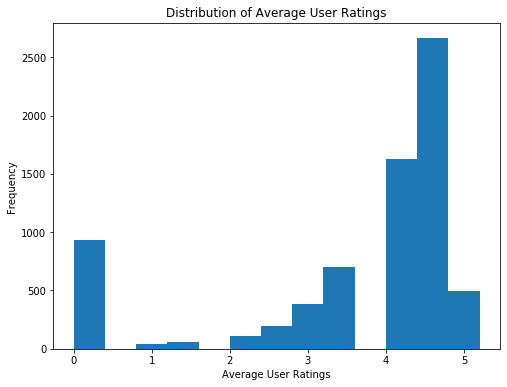

```python
plt.figure(figsize=(8,6))

#Lowering the bin size helps showing that most of ratings are around 4 and 4.5, not 5.
bins = np.arange(0,apps.avg_ratings.max()+0.4,0.4)
plt.hist(data=apps,x='avg_ratings',bins=bins);
plt.xlabel('Average User Ratings');
plt.ylabel('Frequency')
plt.title('Distribution of Average User Ratings')
plt.show()
```

Most apps are distributed to the right, which means they have a good rating.  
The 0's are unrated apps, they probably have a low install or users count.

As a note, any rating below 4 is not considered a successful/good app, as most users won't download apps with low average ratings.

Now we should take a look at a very important variable: price

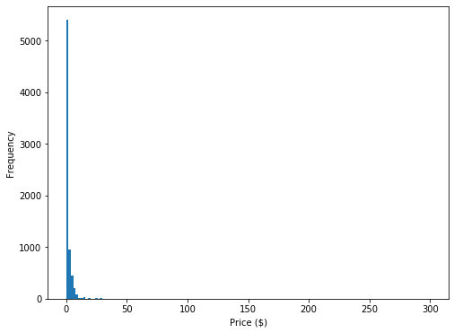

```python
plt.figure(figsize=(8,6))

bins = np.arange(0,apps.price.max()+2,2)

plt.hist(data=apps,x='price',bins=bins);
plt.xlabel('Price ($)');
plt.ylabel('Frequency')
plt.show()
```

Aside from the fact that most apps are in fact free, It's hard to see anything else, because there are some outliers.  
A log scale will help:

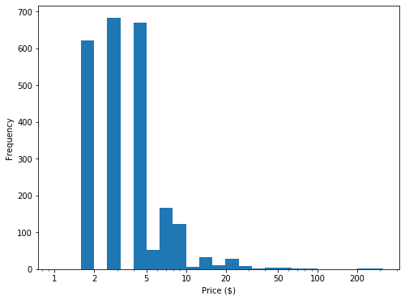

```python
plt.figure(figsize=(8,6))

bins = 10 ** np.arange(0,np.log10(apps.price.max())+0.1,0.1)

plt.hist(data=apps,x='price',bins=bins);
plt.xlabel('Price ($)');
plt.xscale('log')
plt.xticks([1,2,5,10,20,50,100,200],[1,2,5,10,20,50,100,200])
plt.ylabel('Frequency')

plt.show()
```

This clearly tells us that for paid apps, prices usually are from 2 to 5$. With some other spikes on 7-9 and around 20.  
Those all are *standard prices*. 0.99,1.99,2.99,3.99, and so on. Other prices exist but aren't as common.  
Overall, therefore, *most apps are priced below **30-35***. Anything above is very rare.

Before I move on, let me show you something you have probably seen before:

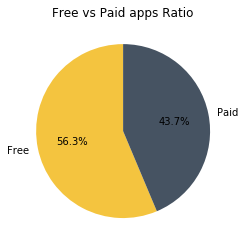

```python
plt.figure(figsize=(4,4))
colors = [light_orange,light_blue]

apps['paid'] = np.where(apps.price > 0,'Paid','Free')
counts = apps.paid.value_counts()
plt.pie(counts,labels=['Free','Paid'],startangle=90,colors=colors,autopct='%1.1f%%');
plt.title('Free vs Paid apps Ratio');
plt.gca().set_aspect('equal')
```

Taking a look on another two interesting variables, languages count and supported devices count:

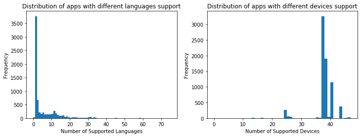

```python
plt.figure(figsize=(12,4))

plt.subplot(1,2,1)

bins = np.arange(0,apps.lang_count.max()+1,1)
plt.hist(data=apps,x='lang_count',bins=bins);
plt.xlabel('Number of Supported Languages');
plt.ylabel('Frequency')
plt.title('Distribution of apps with different languages support')

plt.subplot(1,2,2)
bins = np.arange(0,apps.supp_devices_count.max()+1,1)
plt.hist(data=apps,x='supp_devices_count',bins=bins);
plt.xlabel('Number of Supported Devices');
plt.ylabel('Frequency')
plt.title('Distribution of apps with different devices support')

plt.show()
```

So for languages, most apps have support for one language only, which I guess is English. I will explore this further later.  
For devices support, most seem to support from 37 to 39 devices, which are probably the current generation (at the time this data was gathered) and previous three generations at the very least.  
It's important to study how this affects the average user rating.

As we can see from the supported languages histogram, some apps have 0 languages.  
I should check them:

```python
apps[apps.lang_count == 0]
```

|  | id | app_name | size_mb | price | ratings_count_tot | ratings_count_ver | avg_ratings | avg_ratings_ver | ver | content_rating | genre | supp_devices_count | sc_count | lang_count | vpp_lic | paid |
| --- | --- | --- | --- | --- | --- | --- | --- | --- | --- | --- | --- | --- | --- | --- | --- | --- |
| 63 | 297694601 | Touchgrind | 55.205888 | 4.99 | 35735 | 378 | 4.0 | 4.5 | 1.5.1 | 4+ | Games | 40 | 0 | 0 | 1 | Paid |
| 1012 | 473596157 | Haunted Halloween Escape | 15.481361 | 0.00 | 11945 | 11863 | 4.5 | 4.5 | 1.1 | 12+ | Games | 47 | 5 | 0 | 1 | Free |
| 1948 | 643165438 | Stellarium Mobile Sky Map | 54.294528 | 2.99 | 64 | 10 | 3.5 | 3.5 | 1.23 | 4+ | Education | 43 | 5 | 0 | 1 | Paid |
| 2587 | 854245283 | Cooking Academy 2: World Cuisine (Full) | 133.746688 | 2.99 | 988 | 530 | 4.5 | 4.5 | 1.0.4 | 4+ | Games | 40 | 5 | 0 | 1 | Paid |
| 2798 | 895875773 | Halo: Spartan Assault | 716.275712 | 2.99 | 920 | 582 | 3.5 | 3.0 | 1.1.1 | 12+ | Games | 37 | 5 | 0 | 1 | Paid |
| 3098 | 932325717 | 诸神战纪竞技场：超神大冒险(无尽关 排行榜 动作类横版过关游戏) | 57.092096 | 0.00 | 0 | 0 | 0.0 | 0.0 | 2000 | 9+ | Games | 40 | 3 | 0 | 1 | Free |
| 3146 | 937258914 | WonderCat Adventures | 74.878976 | 2.99 | 93 | 53 | 4.0 | 4.0 | 1.2 | 4+ | Games | 38 | 5 | 0 | 1 | Paid |
| 3170 | 940249281 | Halo: Spartan Strike | 802.975744 | 2.99 | 1159 | 660 | 4.0 | 3.5 | 1.1 | 12+ | Games | 37 | 5 | 0 | 1 | Paid |
| 3325 | 953454701 | センバツLIVE!2017／第89回選抜高校野球大会公式アプリ | 60.797952 | 0.00 | 0 | 0 | 0.0 | 0.0 | 5.5.4 | 4+ | News | 37 | 0 | 0 | 1 | Free |
| 3336 | 954205285 | 戦艦帝国-200艘の実在戦艦を集めろ (2周年記念&世界2000万DL) | 127.147008 | 0.00 | 12 | 1 | 4.0 | 2.0 | 1.0.19 | 12+ | Games | 40 | 5 | 0 | 1 | Free |
| 3384 | 959451726 | ごちうさアラーム～チノ編～ | 18.604032 | 5.99 | 2 | 2 | 5.0 | 5.0 | 1.0.1 | 9+ | Entertainment | 38 | 0 | 0 | 1 | Paid |
| 3571 | 976071352 | スロットマニア・フィーバー～本場ラスベガススロット | 131.524608 | 0.00 | 11 | 0 | 4.5 | 0.0 | 3.9.0 | 12+ | Games | 38 | 5 | 0 | 1 | Free |
| 3706 | 987868589 | 培训题库 | 51.246080 | 1.99 | 0 | 0 | 0.0 | 0.0 | 3.10 | 4+ | Education | 37 | 5 | 0 | 1 | Paid |
| 3721 | 988627776 | モン娘は～れむ【モンはれ】 | 140.779520 | 0.00 | 5 | 0 | 4.0 | 0.0 | 4.2.0 | 17+ | Games | 38 | 5 | 0 | 1 | Free |
| 3778 | 993093969 | 懸賞パズルパクロス２ | 187.141120 | 0.00 | 0 | 0 | 0.0 | 0.0 | 1.10 | 17+ | Games | 40 | 5 | 0 | 1 | Free |
| 3961 | 1011132019 | NOISE | 99.423232 | 0.00 | 355 | 5 | 3.0 | 2.0 | 2.3.3 | 4+ | Music | 25 | 5 | 0 | 1 | Free |
| 4571 | 1051195210 | Xyngular Back Office | 13.839360 | 1.99 | 0 | 0 | 0.0 | 0.0 | 2.1 | 4+ | Business | 38 | 0 | 0 | 1 | Paid |
| 4762 | 1059718989 | 雨时 | 117.463040 | 0.99 | 10 | 0 | 4.5 | 0.0 | 1.7 | 4+ | Weather | 37 | 0 | 0 | 1 | Paid |
| 4856 | 1063211448 | PINGPONG（ピンポン）- 君の反射神経Lvはいくつ？ | 132.924416 | 0.00 | 0 | 0 | 0.0 | 0.0 | 1.5 | 4+ | Games | 40 | 0 | 0 | 1 | Free |
| 5014 | 1068847177 | Monster Tail | 140.006400 | 0.00 | 998 | 155 | 4.0 | 4.5 | 1.6 | 9+ | Games | 37 | 5 | 0 | 1 | Free |
| 5167 | 1073862417 | 你我贷理财-基金理财工具 | 45.742080 | 0.00 | 0 | 0 | 0.0 | 0.0 | 5.2.0 | 17+ | Finance | 38 | 4 | 0 | 1 | Free |
| 5168 | 1073863728 | 你我贷理财-P2P理财管家 | 45.746176 | 0.00 | 0 | 0 | 0.0 | 0.0 | 5.2.0 | 17+ | Finance | 38 | 4 | 0 | 1 | Free |
| 5221 | 1076211312 | PROF - 共通点で楽しむSNS | 119.186432 | 0.00 | 0 | 0 | 0.0 | 0.0 | 5.1 | 17+ | Photo & Video | 37 | 5 | 0 | 1 | Free |
| 5450 | 1084979184 | 鬼畜三国-红将觉醒 | 213.086208 | 0.00 | 0 | 0 | 0.0 | 0.0 | 4.7.02 | 12+ | Games | 40 | 5 | 0 | 1 | Free |
| 5688 | 1093180069 | Civil War: 1861 | 203.193344 | 1.99 | 6 | 6 | 5.0 | 5.0 | 1.1 | 12+ | Games | 37 | 5 | 0 | 1 | Paid |
| 5751 | 1095583219 | 【完全無料】おとな専用！出会い掲示板 | 3.217408 | 0.00 | 0 | 0 | 0.0 | 0.0 | 1.0.2 | 17+ | Social Networking | 37 | 0 | 0 | 1 | Free |
| 5885 | 1102291071 | ピンポンカーブ 君の反射神経Lvはいくつ？ #天才求ム | 128.066560 | 0.00 | 0 | 0 | 0.0 | 0.0 | 1.2 | 4+ | Games | 38 | 0 | 0 | 1 | Free |
| 6046 | 1110286206 | MOBA Legends | 699.091968 | 0.00 | 1815 | 67 | 4.0 | 4.0 | 1.3.1 | 9+ | Games | 37 | 5 | 0 | 1 | Free |
| 6055 | 1110657008 | 帝国征服者-王者联盟列国纷争 | 83.196928 | 0.00 | 0 | 0 | 0.0 | 0.0 | 3.1.0 | 12+ | Games | 40 | 5 | 0 | 1 | Free |
| 6183 | 1116622769 | 坦克新纪元——经典红警狂热回归 | 53.628928 | 0.00 | 0 | 0 | 0.0 | 0.0 | 1.01 | 4+ | Games | 40 | 5 | 0 | 1 | Free |
| 6385 | 1126296052 | 勇士与魔龙 | 199.591936 | 0.00 | 0 | 0 | 0.0 | 0.0 | 1.0.8 | 4+ | Games | 40 | 5 | 0 | 1 | Free |
| 6462 | 1130830362 | SPEED:3D Racing | 127.711232 | 0.00 | 0 | 0 | 0.0 | 0.0 | 1.1 | 4+ | Games | 37 | 0 | 0 | 1 | Free |
| 6870 | 1153896723 | Icy Ropes | 93.580288 | 0.00 | 1931 | 183 | 4.0 | 4.5 | 1.12 | 4+ | Games | 37 | 5 | 0 | 1 | Free |
| 6914 | 1157792207 | 无敌战舰-经典策略海战巅峰对决 | 63.064064 | 0.00 | 0 | 0 | 0.0 | 0.0 | 1.1.2 | 4+ | Games | 40 | 5 | 0 | 1 | Free |
| 6981 | 1163675628 | 仙侠剑客—大型3D精品ARPG动作神作 | 179.085312 | 0.00 | 0 | 0 | 0.0 | 0.0 | 1.1 | 9+ | Games | 40 | 5 | 0 | 1 | Free |
| 7005 | 1164765952 | Dungeon Witcher | 102.876160 | 0.00 | 5 | 3 | 2.5 | 3.5 | 1.2.0 | 12+ | Games | 40 | 5 | 0 | 1 | Free |
| 7025 | 1167651042 | Demi Lovato - Zombarazzie Adventure | 87.374848 | 0.00 | 690 | 136 | 5.0 | 4.5 | 1.4 | 4+ | Games | 37 | 5 | 0 | 1 | Free |
| 7079 | 1173383977 | 修仙侠侣-正统中国风仙侠新作 | 150.490112 | 0.00 | 0 | 0 | 0.0 | 0.0 | 1.0 | 9+ | Games | 40 | 5 | 0 | 1 | Free |
| 7080 | 1173385518 | 逍遥修仙-掌上360度自由视角经典仙侠动作游戏 | 148.481024 | 0.00 | 0 | 0 | 0.0 | 0.0 | 1.0 | 9+ | Games | 40 | 5 | 0 | 1 | Free |
| 7179 | 1185428381 | 剑倚手游 | 178.160640 | 0.99 | 0 | 0 | 0.0 | 0.0 | 1.0 | 9+ | Games | 40 | 5 | 0 | 1 | Paid |
| 7182 | 1185731859 | 剑客情缘-高爆率高掉落天天疯玩 | 171.944960 | 0.00 | 0 | 0 | 0.0 | 0.0 | 1.0 | 9+ | Games | 40 | 5 | 0 | 1 | Free |

Most of these apps aren't named in english, which suggests they are aimed at a small target market, which also means they probably support one language. Since every app can support at least one language, I will set all those to 1

```python
apps.loc[apps[apps.lang_count == 0].index,'lang_count'] = 1
```

We still have two other numeric variables to introduce, screenshot count and app size in megabytes.

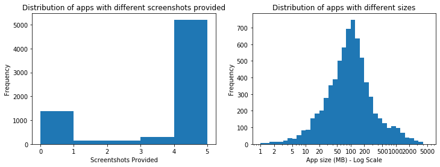

```python
plt.figure(figsize=(12,4))

plt.subplot(1,2,1)

bins = np.arange(0,apps.sc_count.max()+1,1)
plt.hist(data=apps,x='sc_count',bins=bins);
plt.xlabel('Screentshots Provided');
plt.ylabel('Frequency')
plt.title('Distribution of apps with different screenshots provided')

#Plotting sizes with a log scale. For two reasons: Values are quite large. And the distribution is heavily right skewed
plt.subplot(1,2,2)
bins = 10 ** np.arange(0,np.log10(apps.size_mb.max())+0.1,0.1)
plt.hist(data=apps,x='size_mb',bins=bins);
plt.xlabel('App size (MB) - Log Scale');
plt.ylabel('Frequency')
plt.xscale('log')
plt.xticks([1,2,5,10,20,50,100,200,500,1000,2000,5000],[1,2,5,10,20,50,100,200,500,1000,2000,5000])
plt.title('Distribution of apps with different sizes')

plt.show()
```

On a normal scale, sizes had a right skewed distribution so I have choosen to plot them on a log scale.  
Now we have a normal distribution, and we can infer that most sizes are around 100.

For screenshots, providing 5 screenshots seems to be the standard, while the zeros are probably due to an error in the data. I won't explore this variable further.

I will start exploring categorical features by plotting the distribution per Genre:

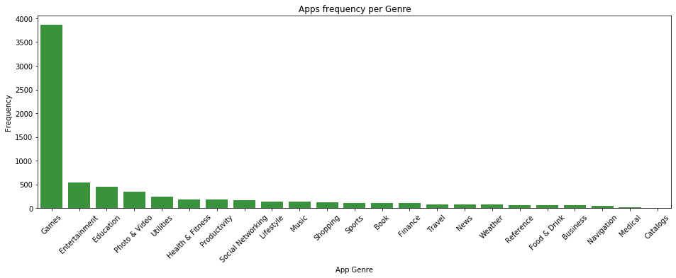

```python
plt.figure(figsize=(16,5))
gen_order = apps.genre.value_counts().index
sb.countplot(data=apps,x='genre',color=green,order=gen_order);
plt.xticks(rotation=45)
plt.xlabel('App Genre')
plt.ylabel('Frequency');
plt.title('Apps frequency per Genre');
```

There are many more games than any other genre, I have to account for this when deriving insight later on.  
Does this change if we take the highest rated apps only?

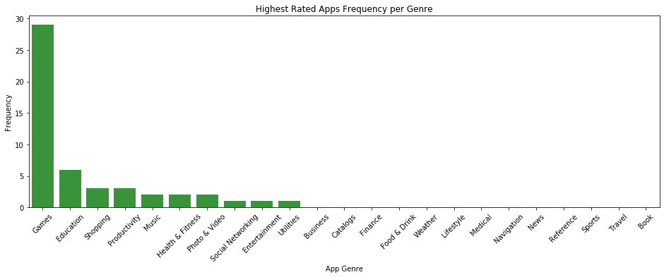

```python
plt.figure(figsize=(16,5))
highest_rating = apps.sort_values(by='avg_ratings',ascending=False).iloc[:50]

gen_order = highest_rating.genre.value_counts().index
sb.countplot(data=highest_rating,x='genre',color=green,order=gen_order);
plt.xticks(rotation=45)
plt.xlabel('App Genre')
plt.ylabel('Frequency');
plt.title('Highest Rated Apps Frequency per Genre');
```

Games still hold their position even when ordering by ratings.  
However, Entertainment category went from the 2nd place to the 9th, this suggests that Entertainment apps have low ratings in general.

Since there are some categories with very low apps count, I will make a new column with the value 'other' for each of these categories, and will keep the name of the category with enough apps count.  
So Game, Eduction will stay as they are while Catalog or medical will become: 'Other'

```python
LOW_THRESHOLD = 150
#Genres with small number of apps
uncommon_genres = apps.genre.value_counts()[apps.genre.value_counts() < LOW_THRESHOLD].index
apps['genre_top'] = apps.genre.astype(str)
apps.loc[apps[apps.genre_top.isin(uncommon_genres)].index,'genre_top'] = 'Other'

#Order the genre_top category
ordinal_top_genres = ['Games','Entertainment','Education','Photo & Video','Utilities','Health & Fitness','Productivity','Social Networking','Other']
ordered_genres = pd.api.types.CategoricalDtype(ordered=True,categories=ordinal_top_genres)

apps.genre_top = apps.genre_top.astype(ordered_genres)
print(uncommon_genres)
apps[apps.genre_top == 'Other'].head(3)
```

```
CategoricalIndex(['Lifestyle', 'Music', 'Shopping', 'Sports', 'Book',
                  'Finance', 'Travel', 'News', 'Weather', 'Reference',
                  'Food & Drink', 'Business', 'Navigation', 'Medical',
                  'Catalogs'],
                 categories=['Book', 'Business', 'Catalogs', 'Education', 'Entertainment', 'Finance', 'Food & Drink', 'Games', ...], ordered=False, dtype='category')
```

|  | id | app_name | size_mb | price | ratings_count_tot | ratings_count_ver | avg_ratings | avg_ratings_ver | ver | content_rating | genre | supp_devices_count | sc_count | lang_count | vpp_lic | paid | genre_top |
| --- | --- | --- | --- | --- | --- | --- | --- | --- | --- | --- | --- | --- | --- | --- | --- | --- | --- |
| 2 | 281940292 | WeatherBug - Local Weather, Radar, Maps, Alerts | 100.524032 | 0.0 | 188583 | 2822 | 3.5 | 4.5 | 5.0.0 | 4+ | Weather | 37 | 5 | 3 | 1 | Free | Other |
| 3 | 282614216 | eBay: Best App to Buy, Sell, Save! Online Shop... | 128.512000 | 0.0 | 262241 | 649 | 4.0 | 4.5 | 5.10.0 | 12+ | Shopping | 37 | 5 | 9 | 1 | Free | Other |
| 4 | 282935706 | Bible | 92.774400 | 0.0 | 985920 | 5320 | 4.5 | 5.0 | 7.5.1 | 4+ | Reference | 37 | 5 | 45 | 1 | Free | Other |

### Unusual points and modifications made

For the lang_count column, some apps had 0 as a value, which isn't possible.  
Upon investigation, it seemed that most of these apps are for a specific target market with a specific language, so I set all their values to 1, which I believe is better than dropping them as I'm in need of a diverse range of apps.

For the genres, some of them had very small number of apps, so to make the analysis easier later on, I made a new column that had a value 'Other' for every uncommon genre (less than X apps, X = threshold), and retained the same value of the orignal genre for every common genre.

## Bivariate Exploration

I will start by exploring the trend between all numeric values of interest:

```python
#To make plots clearer and rendering faster
samples = np.random.choice(apps.shape[0],2000,replace=False)
temp_apps = apps.loc[samples,:]
#To make sure I don't log a zero value
temp_apps = temp_apps[(temp_apps.ratings_count_tot > 0) & (temp_apps.size_mb > 0)].copy()
#Use the log for variables with highly skewed distribution or large range of values
num_apps = pd.DataFrame([temp_apps.price,np.log10(temp_apps.ratings_count_tot),temp_apps.avg_ratings,temp_apps.supp_devices_count,
                         temp_apps.lang_count,np.log10(temp_apps.size_mb),temp_apps.paid]).transpose()
num_apps.describe()
```

|  | price | ratings_count_tot | avg_ratings | supp_devices_count | lang_count | size_mb | paid |
| --- | --- | --- | --- | --- | --- | --- | --- |
| count | 1736.0 | 1736.0 | 1736.0 | 1736 | 1736 | 1736.000000 | 1736 |
| unique | 23.0 | 1182.0 | 9.0 | 17 | 44 | 1730.000000 | 2 |
| top | 0.0 | 0.0 | 4.5 | 37 | 1 | 1.680731 | Free |
| freq | 945.0 | 34.0 | 744.0 | 792 | 875 | 2.000000 | 945 |

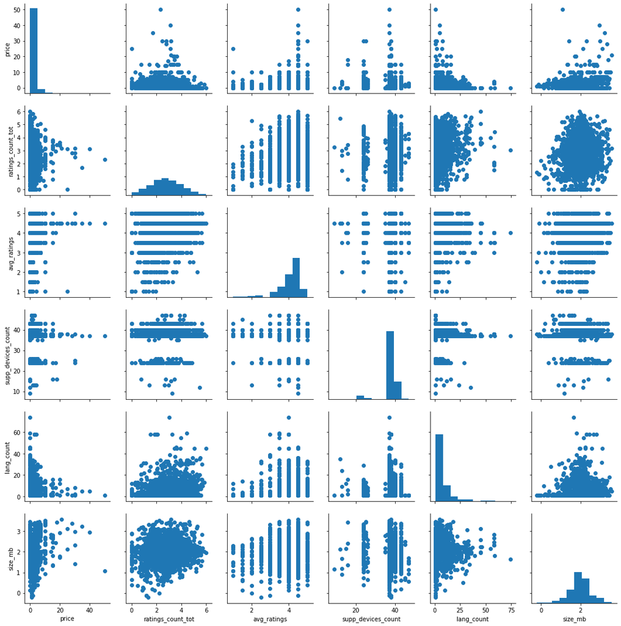

```python
grid = sb.PairGrid(data=num_apps)

grid.map_offdiag(plt.scatter)
grid.map_diag(plt.hist)
```

I can note few observations regarding the _avg*ratings* and _ratings_count*tot* variables.

1. For Paid apps, higher prices are associated with better average ranking.
2. However, higher priced apps are also associated with less total ratings count, which may be the reason for their better average rankings
3. As the number of supported devices increases, we can see more total ratings, but we there would be more chance for apps to have lower average ratings.
4. Generally, apps with more languages supported have better average ratings.
5. Apps with larger sizes have better average ratings overall.

Those notes are very general and require further exploration, however they are important as they point me in specific directions.

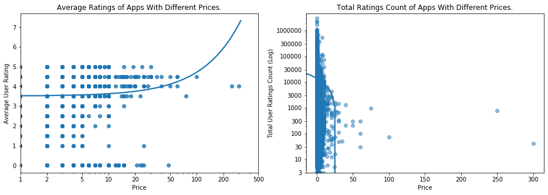

```python
#Plotting Prices vs Average Rating, and Price vs Total ratings count on a log scale
plt.figure(figsize=(16,5))
plt.subplot(1,2,1)

sb.regplot(data=apps,x='price',y='avg_ratings',ci=None)
plt.ylabel('Average User Rating')
plt.xlabel('Price')
plt.xscale('log')
xticks = [1,2,5,10,20,50,100,200,500]
plt.xticks(xticks,xticks)
plt.title('Average Ratings of Apps With Different Prices.')

plt.subplot(1,2,2)
plt.yscale('log')
sb.regplot(data=apps,x='price',y='ratings_count_tot',ci=None,scatter_kws={'alpha':1/2})
plt.ylabel('Total User Ratings Count (Log)')
plt.xlabel('Price')
log_ticks = [3,10,30,100,300,1000,3000,10000,30000,100000,300000,1000000]
plt.yticks(log_ticks,log_ticks);
plt.title('Total Ratings Count of Apps With Different Prices.');
```

As before, we see here that as the price increases, for paid apps, we can expect a better rating.  
To know whether or not the increase in average ratings is due to the decrease in total ratings count ..  
I should look at the plot of Average Ratings over Total Ratings Count:

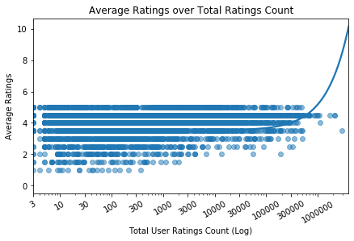

```python
plt.figure(figsize=(7,4))
plt.xscale('log')
sb.regplot(data=apps,y='avg_ratings',x='ratings_count_tot',ci=None,scatter_kws={'alpha':1/2})
plt.xlabel('Total User Ratings Count (Log)')
plt.ylabel('Average Ratings')
plt.title('Average Ratings over Total Ratings Count')

plt.xticks(log_ticks,log_ticks,rotation=30);
```

The plot here tells us that as the total ratings count increases, generally, the average ratings increase as well.  
While there are lots of apps with low rating count and high average rating, there isn't a *negative trend* between them so we **can't** say that the *low rating is correlated with higher average ratings*.

Since the above plots gave us the correlation as the price increases for paid apps, we still can't determince whether Paid or Free apps actually have the best ratings overall.  
So I must plot the distribution:

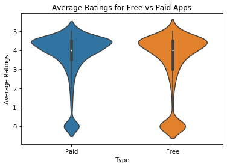

```python
sb.violinplot(data=apps,x='paid',y='avg_ratings')
plt.ylabel('Average Ratings')
plt.xlabel('Type')
plt.title('Average Ratings for Free vs Paid Apps');
```

While the distributions look similar, paid apps have generally more apps on the higher end rather than the lower end, suggesting that Paid apps have better average ratings overall, as expected,

Now I will explore the relation between the other numeric variables and the average rating through a small heatmap:

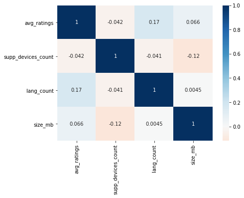

```python
plt.figure(figsize=(7,5))
sb.heatmap(apps[['avg_ratings','supp_devices_count','lang_count','size_mb']].corr(),annot=True,cmap='RdBu',center=0);
```

Surprisingly, there's a negative correlation between the number of supported devices and the average ratings.  
This may be because apps with wider support of devices do support old devices as well, users of which might find more problems or issues with the said app thus giving a bad rating.

For the other two variables, we have a positive correlation, and they are worth more investigation later on.

#### Exploring categorical variables

Now we should explore some categorical variables and see how they affect other features, specifically, ratings.  
Let's start with a plot of ratings and genres:

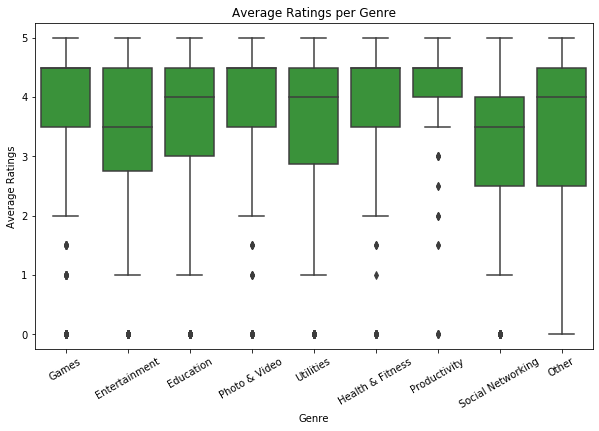

```python
plt.figure(figsize=(10,6))
gen_order = apps.genre_top.value_counts().index
sb.boxplot(data=apps,x='genre_top',y='avg_ratings',color=green)
plt.xticks(rotation=30)
plt.xlabel('Genre')
plt.ylabel('Average Ratings')
plt.title('Average Ratings per Genre');
```

Interestingly, Productivity apps have the best ratings distribution of all, with the exception of the outliers.  
This might be because there is a small number of them, but Social Neworking apps have worse ratings and less number, so this isn't the cause.  
Entertainment, Utilities and Social Networking genres have a wider range of ratings, which is probably due to the fact that these genres are quite general and include many different sub-categories.  
The same goes for Other genres.

We saw earlier that pricier apps generally have better ratings, so let's see how different genres apps are priced and whether or not that's related to the average ratings.  
I will go for a FacetGrid:

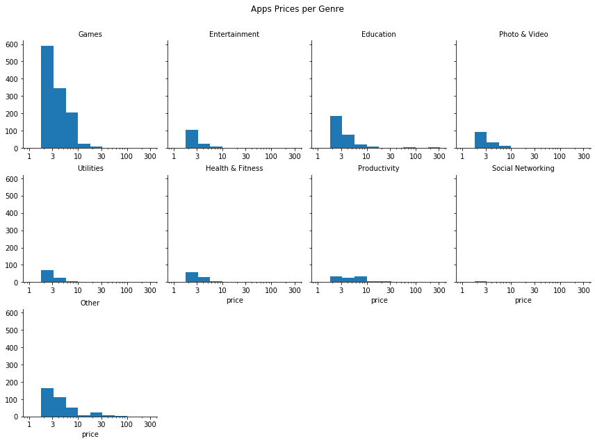

```python
#bin_edges = np.arange(0,apps.price.max()+0.5,0.5)
bin_edges = 10 ** np.arange(0,np.log10(apps.price.max())+0.25,0.25)

#apps['price_log10'] = np.log10(apps.price)
grid = sb.FacetGrid(data=apps,col='genre_top',col_wrap=4)
grid.map(plt.hist,"price",bins=bin_edges)
plt.xscale('log')
grid.set_titles('{col_name}')
xticks = [1,3,10,30,100,300]
plt.xticks(xticks,xticks)
#Label the ticks for every plot (Axis)
for ax in grid.axes.flatten():
    ax.tick_params(labelbottom=True)

#So that the title doesn't overlap
plt.subplots_adjust(top=0.9)
grid.fig.suptitle('Apps Prices per Genre');
```

So actually most genres have similar distribution shapes, they all are right skewed with most prices ranging from 2 (most) to 10 (least) dollars.  
Productivity apps have similar range but a different shape, while almost all Social Networking apps are Free.

**Takeaway:**

- Generally, try to keep your app price below 10 dollars. For Games, you have more freedom, as you can go up to 30, the same goes Education apps.

Now, as before, this doesn't distinguish between Free and Paid apps, we have to plot that on its own:

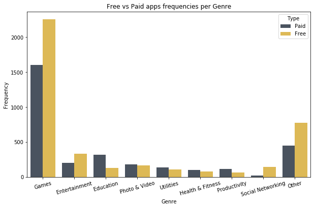

```python
plt.figure(figsize=(10,6))
sb.countplot(data=apps,x='genre_top',hue='paid',palette = {'Paid':light_blue,'Free':light_orange})
plt.xticks(rotation=15);
plt.legend(title='Type');
plt.ylabel('Frequency')
plt.xlabel('Genre')
plt.title('Free vs Paid apps frequencies per Genre');
```

That's some valuable information.  
The genres Education, Photo & Video, Utilities, Health & Fitness and Productivity all had more paid apps than free apps, which signs that there are legit companies working behind those genres' apps.  
This also shows us a correlation between the rankings, that, except for games, **genres which have more paid apps than free also have better rankings distributions overall**. (Check the box plot of before)

**Takeaway:**

- If you're making a Social Networking app, you better make it free. For other genres, like Education, you can find an audience that would happily buy your app.
- If you're making a game, then, generally, you will find an audience whether its Free or Paid. But you will find more players if you published it free.

Before moving on, I want to see how are content ratings distributed per genre:

```python
#percentages of each content rating in each genre
perc = apps.groupby("genre_top")['content_rating'].value_counts(normalize=True).unstack()
perc = perc.reset_index().melt(id_vars='genre_top')
perc.content_rating = perc.content_rating.astype(ordered_cont)
```

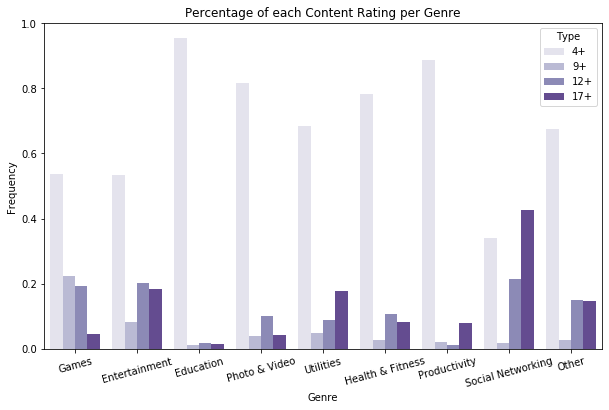

```python
plt.figure(figsize=(10,6))
sb.barplot(data=perc,x='genre_top',y='value',hue='content_rating',palette='Purples')
plt.xticks(rotation=15);
plt.legend(title='Type');
plt.ylabel('Frequency')
plt.xlabel('Genre')
plt.title('Percentage of each Content Rating per Genre');
```

Since most apps are 4+, let's see if there's a difference in rating for different content ratings.

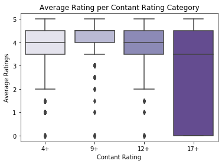

```python
sb.boxplot(data=apps,x='content_rating',y='avg_ratings',palette='Purples')
plt.xlabel('Contant Rating')
plt.ylabel('Average Ratings')
plt.title('Average Rating per Contant Rating Category');
```

This makes sense. Apps with low content rating have more users thus more ratings (ratings_count_tot) therefore they have better average rating.  
While apps with higher content rating (17+) are 1) less in number and 2) targeted to specific audience, so they get more critical reviews thus a wider range of average ratings.

##### What genres have the widest range of devices support? What about langauges support?

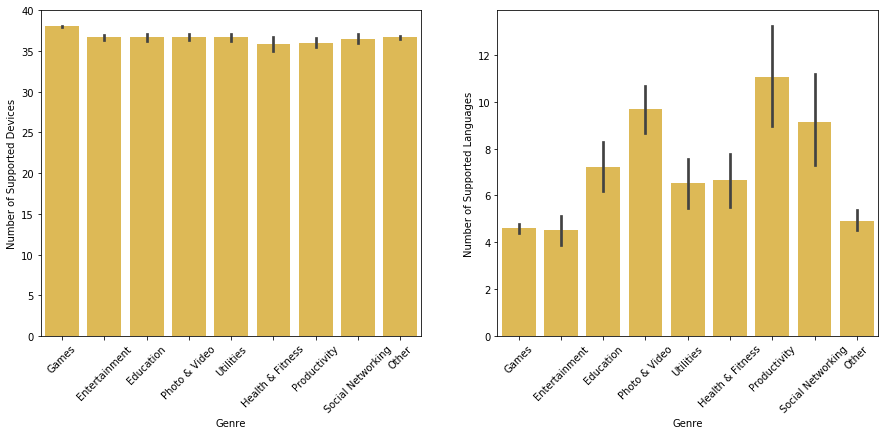

```python
plt.figure(figsize=(15,6))
plt.subplot(1,2,1)
sb.barplot(data=apps,x='genre_top',y='supp_devices_count',color=light_orange)
plt.xticks(rotation=45);
plt.xlabel('Genre')
plt.ylabel('Number of Supported Devices')
plt.subplot(1,2,2)
sb.barplot(data=apps,x='genre_top',y='lang_count',color=light_orange)
plt.xticks(rotation=45);
plt.xlabel('Genre')
plt.ylabel('Number of Supported Languages');
```

It seems that no specific genre has notably greater support for devices than others, except that Games are a little bit better.  
For langauges, however, apps of work related genres like Productivity Photo & Video and Social Networking certainly support more languages.

##### Which genres' apps have largest sizes?

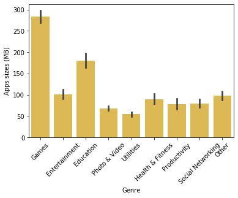

```python
sb.barplot(data=apps,x='genre_top',y='size_mb',color=light_orange)
plt.xticks(rotation=45);
plt.xlabel('Genre')
plt.ylabel('Apps sizes (MB)');
```

As expected, Games take the most from a device memory.

**Takeaway:**

- If you're making a Photo & Video, Social Networking or Productivity app, you should generally support a wide range of languages.
- If you're making a Utilities, Social Networking or Photo & Video apps, you should try to minimize the size of your apps.

### Observations: How did the features of interest vary with other features in the data set?

The average rating had a positive correlation with the prices for paid apps, not a weak nor a very strong correlation, a middle one. I noted that even though paid apps have less ratings count, this doesn't mean that this is the *cause* of having better average ratings, since average ratings generally increase as the rating counts increase. A violin plot also confirmed that Paid apps generally have better average ratings than free apps.

Investigating other numeric variables of interest showed that apps with more languages supported have better rankings overall, and larger app sizes correlated with better ratings, while a wider devices support didn't prove to be effective. In fact, the correlation coefficient shows that the more devices the app supports, the worse its average rating might be.

For categorical features, few genres had beaten others in having the best average ratings, notably: **Productivity, Photo & Video and Games** genres had the best ratings distributions. Also, apps with content rating 17+ have generally less average ratings.

I will explore the relation between ratings, price, genres, supported languages and apps sizes more in the next section.

### Interesting relationships between the other features (not the main feature(s) of interest)

As stated earlier, I planned to look into other features and their correlations outside the main feature, average rating.  
Work related genres like Productivity, Photo & Video and Social Networking apps support many more languages than apps of other genres.  
Prices of apps slightly varied with genres; While all almost genres have similar right skewed distrubiton of prices, **Productivity** apps have a similar range but a different shape, and a lot of **Social Networking** apps are Free (or low priced).  
Furthermore, Education, Photo & Video, Utilities, Health & Fitness and Productivity all had more Paid apps than Free apps.

Those features may not be explored further.

## Multivariate Exploration

In this section I will explore how the ratings (average or total) relate to price, supported langauges and apps size at the same time and how they differ accross genres.

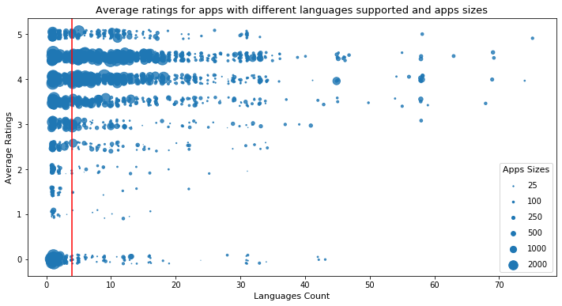

```python
plt.figure(figsize=(12,6))
sb.regplot(data=apps,x='lang_count',y='avg_ratings',fit_reg=False,x_jitter=0.2,y_jitter=0.1,scatter_kws={'s':apps.size_mb/15},color=blue);

sizes = [25,100,250,500,1000,2000]
sizes[:] = [x  for x in sizes]

legend_obj = []
for s in sizes:
    legend_obj.append(plt.scatter([], [], s = s/15, color = blue))
plt.legend(legend_obj, sizes,title='Apps Sizes',labelspacing=1,title_fontsize=11)

plt.ylabel('Average Ratings',fontsize=11)
plt.xlabel('Languages Count',fontsize=11);
plt.title('Average ratings for apps with different languages supported and apps sizes',fontsize=13)
plt.axvline(x=4,color='red')
```

While we do see a good % of apps with larger sizes on higher rating, there are also low rated apps with lower sizes.  
But most apps on higher ratings are of large size, like greater than 100 mb.  
As for languages, most of apps with more than one language are distributed on the higher end of average ratings (between 3.5 and 4.5).  
Specicially, apps with 4 or more languages supported have higher ratings overall.

Since the plot above doesn't make it clear where are most apps distributed (For apps with 1-2 languages, are most of them rated low or high?)..  
I will plot a heatmap

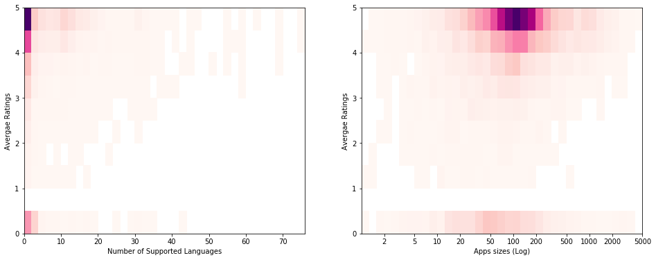

```python
plt.figure(figsize=(16,6))
plt.subplot(1,2,1)

xbins = np.arange(0,apps['lang_count'].max()+2,2)
ybins = np.arange(0,apps['avg_ratings'].max()+0.5,0.5)
plt.hist2d(apps['lang_count'],apps['avg_ratings'],cmin=0.5,cmap='RdPu',bins=[xbins,ybins]);
#plt.colorbar(label = 'Frequency')
plt.xlabel('Number of Supported Languages')
plt.ylabel('Avergae Ratings');

plt.subplot(1,2,2)
xbins = np.arange(0,np.log10(apps['size_mb']).max()+0.1,0.1)
#ybins = np.arange(0,np.log10(apps['size_mb']).max()+0.25,.25)

ybins = np.arange(0,apps['avg_ratings'].max()+0.5,0.5)
plt.hist2d(np.log10(apps['size_mb']),apps['avg_ratings'],cmin=0.5,cmap='RdPu',bins=[xbins,ybins]);
#plt.colorbar(label = 'Frequency')
plt.ylabel('Avergae Ratings');
plt.xlabel('Apps sizes (Log)');
yticks = [2,5,10,20,50,100,200,500,1000,2000,5000]
plt.xticks(np.log10(yticks),yticks);
```

Looks like even apps with 1-2 language take up mostly, high ratings. However, as the count increases, the ratings certainly get better.

**Tips**

1. More content = larger sizes = generally better average ratings
2. Support at least 4 languages. Not any 4, of course. You probably need to support **English, Hindustani, Spanish and Arabic**. (Don't forget **Chineese** if your app is global!)

How much would it cost if you were to increase the size and support a wider range of languages?  
A plot of price versus size and languages would help answering this.

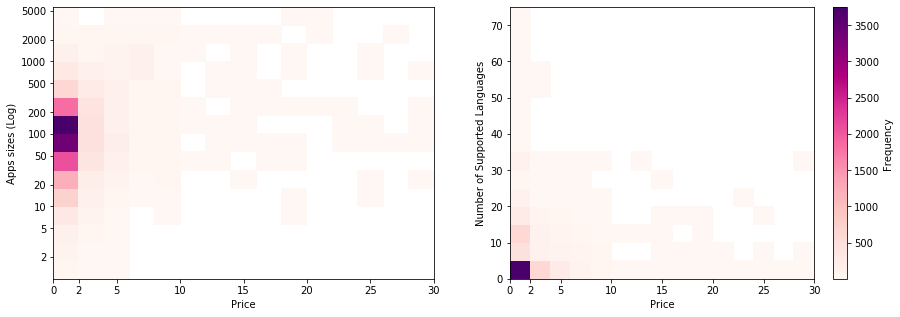

```python
plt.figure(figsize=(15,5))
xbins = np.arange(0,apps['price'].max()+2,2)
ybins = np.arange(0,np.log10(apps['size_mb']).max()+0.25,.25)

plt.subplot(1,2,1)
plt.hist2d(apps['price'],np.log10(apps['size_mb']),cmin=0.5,cmap='RdPu',bins=[xbins,ybins]);

plt.xlabel('Price')
plt.xlim(0,30)
plt.xticks([0,2,5,10,15,20,25,30]);

plt.ylabel('Apps sizes (Log)');
yticks = [2,5,10,20,50,100,200,500,1000,2000,5000]
plt.yticks(np.log10(yticks),yticks);
plt.subplot(1,2,2)

ybins =  np.arange(0,apps['lang_count'].max()+5,5)
plt.hist2d(apps['price'],apps['lang_count'],cmin=0.5,cmap='RdPu',bins=[xbins,ybins]);
plt.xlabel('Price')
plt.xlim(0,30)
plt.xticks([0,2,5,10,15,20,25,30]);

plt.ylabel('Number of Supported Languages')
plt.colorbar(label = 'Frequency')
```

Apparently, sizes don't affect the prices much. Most apps with reasonable sizes are priced 2 or less. Of which most are probably free.  
Languages as well don't seem to have any specific distribution, apart from the fact that most apps have less than 5 and are also priced less than 2.  
This isn't a coincidence. Lots of apps in our dataset are priced below 2.

**Takeaway:**

- You should not hesitate to increase your app size, and you should support a wide enough range of languages, without overpricing your app.

Now an important question would arise: Would these points change for different genres? Let's see.

```python
def hist2dgrid(x, y,xbinsize=1,ybinsize=1 ,**kwargs):
    palette = kwargs.pop('color')
    bins_x = np.arange(x.min(), x.max()+xbinsize, xbinsize)
    bins_y= np.arange(y.min(), y.max()+ybinsize, ybinsize)
    #ax = plt.gca()
    plt.hist2d(x, y, bins = [bins_x, bins_y], cmap = palette, cmin = 0.5)
    #ax.figure.colorbar()
```

```python
apps['size_mb_log'] = np.log10(apps['size_mb'])
```

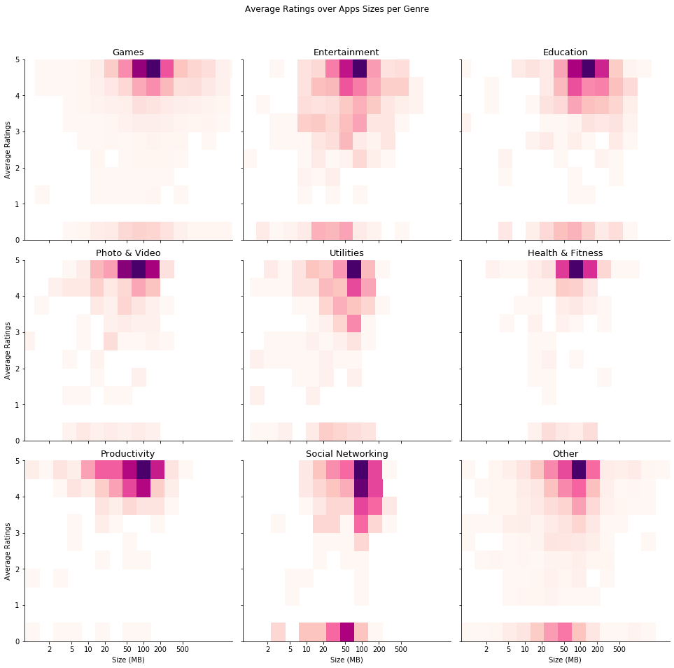

```python
grid = sb.FacetGrid(data = apps, col = 'genre_top', col_wrap = 3, height = 4.5)
grid.map(hist2dgrid, 'size_mb_log', 'avg_ratings',xbinsize = 0.25,ybinsize = 0.5, color = 'RdPu')

xticks = [2,5,10,20,50,100,200,500]
plt.xticks(np.log10(xticks),xticks);

grid.set_xlabels('Size (MB)')
grid.set_ylabels('Average Ratings')

grid.set_titles('{col_name}')


#Label the ticks for every plot (Axis)
for ax in grid.axes.flatten():
    #ax.tick_params(labelbottom=True)
    ax.set_title(ax.get_title(),fontsize=13)

#So that the title doesn't overlap
plt.subplots_adjust(top=0.9)
grid.fig.suptitle('Average Ratings over Apps Sizes per Genre');

plt.show()
#plt.tight_layout()
grid.fig.tight_layout()
#plt.colorbar()
plt.subplots_adjust(hspace=1, wspace=0.4)
```

Not surprisingly, most genres have their apps with sizes ranging from around 50 MB to 100 MB, and those are the sizes that are the most common and a large % of the best rated apps have sizes close or within this range.

However, there aren't many apps outside this range. For example, there are not many apps with sizes less than 20 nor many over 300, which is why we see less apps rated over 4, and **not** because low or high size apps can't get a good rating.

So sizes seem to be the *norm* along the apps with good ratings, but they don't seem to be a good *cause* for good ratings.

**Tips**

- Try to keep your app size between 50 and 250-300 MB. If you're going for a game, entertainment or education apps, you can go higher, but try to stay below 500 MB

I will take a look at how this differs for number of supported languages.

[figure not shown]

```python
grid = sb.FacetGrid(data = apps, col = 'genre_top', col_wrap = 3, height = 4.5)
grid.map(hist2dgrid, 'lang_count', 'avg_ratings',xbinsize = 2,ybinsize = 0.5, color = 'RdPu')

grid.set_xlabels('Number of Supported Languages',fontsize=12)
grid.set_ylabels('Average Ratings',fontsize=12)

grid.set_titles('{col_name}')


#Label the ticks for every plot (Axis)
for ax in grid.axes.flatten():
    #ax.tick_params(labelbottom=True)
    ax.set_title(ax.get_title(),fontsize=13)

#So that the title doesn't overlap
plt.subplots_adjust(top=0.9)
grid.fig.suptitle('Average Ratings over Apps Sizes per Genre',fontsize=14);

plt.show()
grid.fig.tight_layout()
```

Most notably, for genres Education, Photo & Video, Utilities, Health & Fitness and Productivity, we see most apps with a wider support for languages have better ratings.  
For other genres, this seems to be less important.

**Takeaway:**

- If you're building an app for **Education, Photo & Video, Utilities, Health & Fitness or Productivity**, you should consider supporting enough languages.

Now I shall explore something important: How do the average ratings look like for Paid vs Free apps **per genre** :

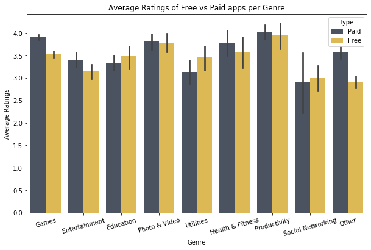

```python
plt.figure(figsize=(10,6))
sb.barplot(data=apps,x='genre_top',y='avg_ratings',hue='paid',palette = {'Paid':light_blue,'Free':light_orange})
plt.xticks(rotation=15);
plt.legend(title='Type');
plt.ylabel('Average Ratings')
plt.xlabel('Genre')
plt.title('Average Ratings of Free vs Paid apps per Genre');
```

What we notice here is that most genres have (albiet slightly for some) better ratings for their paid apps, which confirms our initial observations that, generally, the pricier the app the better its average ratings.  
But the genres Education, Utilities and Social networking break this "rule", why?

It's simple to explain it for Social Networking: There are many more Free Social Networking apps than paid, so it's reasonable to have better ratings for them. (Note: While the difference is less than expected, note that the confidence interval of Paid SN apps is wider than the one for Free apps).

For Education and Utilities, they both have more paid apps than free..  
Maybe because people generally prefer free apps over paid apps for that those genres, they get higher ratings?  
I think a different plot can answer this.

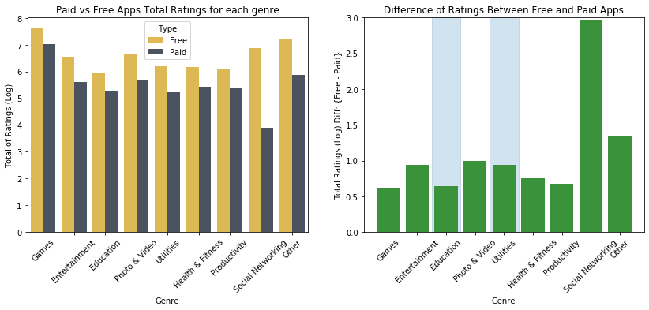

```python
plt.figure(figsize=(14,5))
#Plotting total ratings count (on a log scale) for each genre, hue by paid vs free
sums = apps.groupby(['genre_top','paid']).sum()['ratings_count_tot'].reset_index()
sums['ratings_count_tot'] = np.log10(sums['ratings_count_tot'] )
plt.subplot(1,2,1)
sb.barplot(data=sums,x='genre_top',y='ratings_count_tot',hue='paid',palette={'Paid':light_blue,'Free':light_orange})
plt.xticks(rotation=45);
plt.xlabel('Genre')
plt.ylabel('Total of Ratings (Log)')
plt.title('Paid vs Free Apps Total Ratings for each genre')
plt.legend(title='Type')
plt.subplot(1,2,2)
#Plotting the difference in the log total ratings count between free and paid apps for each genre
diffs = sums.copy()
diffs['diff'] = sums.groupby('genre_top').diff().abs()
diffs = diffs.dropna().reset_index(drop=True)
diffs['rel_diff'] = diffs['diff'] / sums[sums['paid'] == 'Free']['ratings_count_tot'].reset_index(drop=True).astype('float')

ax = sb.barplot(data=diffs,x='genre_top',y='diff',color=green)
ax.fill_between([1.5 ,2.5], 3, alpha=.2,color=blue)
ax.fill_between([3.5,4.5], 3, alpha=.2 ,color=blue)
ax.set_ylim([0,3])

plt.xticks(rotation=45);

plt.xlabel('Genre')
plt.ylabel('Total Ratings (Log) Diff: {Free - Paid}')
plt.title('Difference of Ratings Between Free and Paid Apps');
```

This explains it. While Education and Utilities genres both have more Paid apps than Free, Free apps get many more ratings than Paid apps, for all genres.  
The plot on the right shows the actual difference, it's almost 5x for Education and 10x for Utilities (The plot shows the log)

Now I would like to see if there are gaps in the market. For example, a genre where there is a small user base and a rating that could be imporved. Or over-saturated markets where the competition is hard.  
I also want to know whether, for each genre, is it better to go for a Free or a Paid app?  
I will plot all genres to answer this.

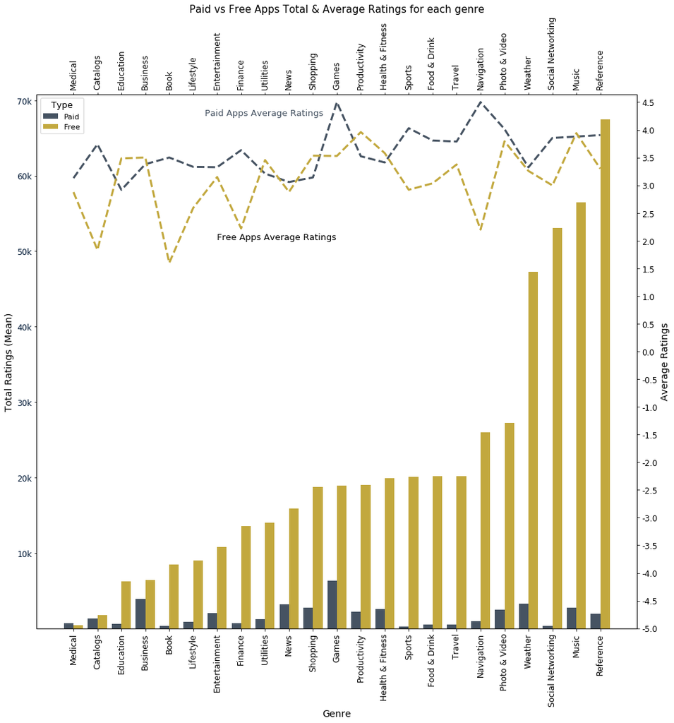

```python
fig, ax1 = plt.subplots(figsize=(14,15))

plt.title('Paid vs Free Apps Total & Average Ratings for each genre',fontsize=15);
fig.subplots_adjust(top=0.8)

sorted_index = apps.query('paid == "Free"').groupby(['genre']).mean()['ratings_count_tot'].sort_values()

paid_sums = apps.query('paid == "Paid"').groupby('genre').mean()['ratings_count_tot'].reindex(sorted_index.index).values
free_sums = apps.query('paid == "Free"').groupby('genre').mean()['ratings_count_tot'].reindex(sorted_index.index).values
#Both paid and free sums have same length
x = np.arange(len(paid_sums))

genre_labels = apps.groupby('genre').mean().reset_index().genre
genre_labels = sorted_index.index

width = 0.4
bars1 = ax1.bar(x - width/2, paid_sums, width, label='Paid',color=light_blue)
bars2 = ax1.bar(x + width/2, free_sums, width, label='Free',color=dark_gold)

# Add some text for labels, title and custom x-axis tick labels, etc.
ax1.set_ylabel('Total Ratings (Mean)',fontsize=14)
ax1.set_xlabel('Genre',fontsize=14)
#Ticks
ax1.set_xticks(x)
ax1.set_xticklabels(genre_labels,fontsize=12,rotation=90)
ax1.tick_params(axis='y', labelcolor=dark_blue)
ax1.set_yticks([1e4,2e4,3e4,4e4,5e4,6e4,7e4])
ax1.set_yticklabels(['10k','20k','30k','40k','50k','60k','70k'],fontsize=12)
#Legend
ax1.legend(title='Type',title_fontsize=13,fontsize=11)

#Clone it on x axis to allow multiple plots in same axes
ax2 = ax1.twinx()
means_paid = apps.query('paid == "Paid"').groupby(['genre']).mean().sort_values(by='ratings_count_tot')['avg_ratings']
means_free = apps.query('paid == "Free"').groupby(['genre']).mean().sort_values(by='ratings_count_tot')['avg_ratings']

ax2.set_zorder(5)
ax2.patch.set_visible(False)


ax2.plot(np.arange(len(means_paid)) ,means_paid.values, color=light_blue, label='Average Ratings - Paid Apps', linewidth=3,linestyle='dashed')
ax2.plot(np.arange(len(means_free)) ,means_free.values, color=dark_gold, label='Average Ratings - Free Apps', linewidth=3,linestyle='dashed')

#Set a wider y range to make the plot more compact
xticks = np.arange(-5, 5, 0.5)
ax2.set_yticks(xticks)
ax2.set_yticklabels(xticks,fontsize=12);
ax2.set_ylabel('Average Ratings',fontsize=14)

ax1.text(5.5, 68000, 'Paid Apps Average Ratings', color=light_blue,fontsize=13)
ax1.text(6,51500, 'Free Apps Average Ratings', color='black',fontsize=13)


ax3=ax1.twiny()
#Plot dummy invisible bars to set the  x ticks positions correctly
rects1 = ax3.bar(x - width/2, 0, width)
rects2 = ax3.bar(x + width/2, 0, width)
ax3.set_xticks(x)
ax3.set_xticklabels(genre_labels,rotation=90,fontsize=12)
ax3.xaxis.set_ticks_position("top")

fig.tight_layout()
plt.show()
```

That was an intense plot. It may seem complicated but this is only because it's large. It shows the total ratings count on the left y axis which are resembled by the bars. And it shows the average ratings on the right y axis which are resembled by the lines.

##### Crowded Markets discussion:

To succeed with a new app, it's best to look for either non-crowded markets, or markets where there is a clear room of imporvement.

From the above plot, non-crowded markets are apps of genres from the left: **Medical, Catalogs, Education, Business**.  
However, you may wish to go for genres where the average ratings are quite low, which are: **Catalogs, Book,Lifestyle and Finance**, to have an easier competition.

Whereas genres with large user bases are crowded and have generally higher mean ratings, there is still a lot to improve in genres like: **Sports, Travel, Food & Drink, Health & Fitness and Shopping**.

##### Free vs Paid apps

Generally, as we have seen before, almost all genres have better ratings for Paid apps. But is this a reliable indiator? There are two things to note here: Since Paid apps have a much smaller userbase, their ratings will only resemble the small group of people who bought the app.

Also, if you don't want a hard competition, you better go for a free app since their average ratings are lower.

Based on that, my suggestions now would be:

- If you're making an app for a nich market, a small target market, and you care more about maintaining its high quality and achiving iats specific goal, then you should consider making it paid. An example would be an app for bank transactions or a medical simulation app for trainees.
- Also, if you're going for a game, then you can go with Free or Paid, you have a large enough user base and can get high ratings either way.
- Otherwise, make your app Free.

### Talk about some of the relationships you observed in this part of the investigation. Were there features that strengthened each other in terms of looking at your feature(s) of interest?

I explored how the features apps size, prices and languages supported affect the averate ratings. My initial observations were correct, the the larger each of these values is, the better the average ratings. However, there are caveats. For languages, having more than 4-5 langauges didn't provide much of an advantage any more . As for sizes, you can have a small app (<50MB) and a high rating, so it's not entirely necessary to have a large app. Though the larger the app, the more likely it would fall into a better rating.

I also saw that apps with large sizes and wide languages support weren't pricey, noting that those are inherent characteristics that users expect, and not really features.  
The investigations I carried out with genres were the most interesting and informative. I noted that some genres expected a wider languages support than others, and some genres had usually large apps sizes.

But the most important observaton is that, while pricier apps correlate with better ratings, it turned out that it's usually better to have your app Free, as it maximizes your total ratings count (and hence user count) which gives much better results overall.

### Were there any interesting or surprising interactions between features?

The 2d histograms languages count and prices showed that apps with wider support for languages were usually priced less than 2 dollars, obviously of which most are free. Another plot showed the more the languages, the higher the ratings. This means that lots of apps with lower prices get high ratings. This may not be an interaction but it tells us how related those features are.